# Set contrasts

Each method’s own Benjamini-Hochberg correction runs within one contrast over every set.

## Packages

```r
library(here)
library(limma)
library(dplyr)
library(tidyr)
library(purrr)
library(tibble)
library(ggplot2)
library(grid)
library(ComplexHeatmap)
source(here("00_Setup", "Shared_functions", "analysis_reporting_helpers.R"))
source(here("00_Setup", "Shared_functions", "proteome_inputs.R"))
c(grouping = params$grouping, input = params$input)
```

```
  grouping      input
"Proteome"       "T3"
```

The protein fit from `02_Protein_Contrasts`, this grouping’s design, the gene sets, limpa’s complete matrix (fry needs one without gaps), the set scores for the overview, and the phenotype for the trait tracks.

```r
input <- params$input[nzchar(params$input)]
step <- \(name) paste(c("03_Group_comparisons", params$grouping, name, input), collapse = "/")
stage <- step("03_Set_Contrasts")
inputs <- c(
  gene_sets = "01_Processing/04_Gene_Sets/c_data/gene_sets.rds",
  fit = file.path(step("02_Protein_Contrasts"), "c_data/fit.rds"),
  design = file.path(step("01_Design_Contrasts"), "c_data/design.rds"),
  limpa = "01_Processing/03_Quantification/c_data/DAList_limpa.rds",
  singscore = "01_Processing/05_Set_Scores/c_data/singscore.rds",
  phenotype = "00_Setup/Input/phenotype.csv"
)
paths <- map_chr(inputs, here)
stopifnot(file.exists(paths))
gs <- readRDS(paths[["gene_sets"]])
fit <- readRDS(paths[["fit"]])
d <- readRDS(paths[["design"]])
complete <- subset_for_design(readRDS(paths[["limpa"]]), d)
sets <- gs$sets
protein_map <- gs$protein_map
protein_ids <- protein_map$uniprot_id
eb <- fit$eBayes_fit
contrast_names <- colnames(fit$design$contrast_matrix)
design <- fit$design$design_matrix
subject <- fit$metadata$subject
```

A stale fit would still line up by count, so these checks compare names, not lengths.

```r
stopifnot(
  identical(rownames(eb$coefficients), protein_ids),
  identical(colnames(eb$coefficients), contrast_names),
  identical(rownames(complete$data), protein_ids),
  identical(colnames(complete$data), rownames(design)),
  identical(fit$metadata$sample_id, rownames(design)),
  d$floor %in% contrast_names
)
c(sets = length(sets), proteins = length(protein_ids), runs = ncol(complete$data))
```

```
    sets proteins     runs
    1378     1900       44
```

## Protein results from the saved fit

`topTable()` rebuilds the nine contrasts from the saved fit, with the same BH within contrast. Π = p^|logFC| marks the proteins the figure steps draw.

```r
protein_results <- map(set_names(contrast_names), function(contrast) {
  topTable(eb, coef = contrast, number = Inf, adjust.method = "BH", sort.by = "none") |>
    rownames_to_column("uniprot_id") |>
    select(uniprot_id, logFC, AveExpr, t, p = P.Value, fdr = adj.P.Val)
}) |>
  list_rbind(names_to = "contrast") |>
  left_join(protein_map, by = "uniprot_id", relationship = "many-to-one") |>
  mutate(pi_score = p^abs(logFC))
stopifnot(nrow(protein_results) == length(protein_ids) * length(contrast_names))
protein_summary <- protein_results |>
  summarise(
    n_tested = n(), n_up = sum(fdr < 0.05 & logFC > 0), n_down = sum(fdr < 0.05 & logFC < 0),
    min_fdr = signif(min(fdr), 3), .by = contrast
  )
protein_summary
```

```
              contrast n_tested n_up n_down  min_fdr
1          Training_C1     1900    0      0 7.35e-01
2          Training_C2     1900    1      0 4.28e-02
3             Acute_C1     1900   60     24 4.37e-05
4             Acute_C2     1900    0      0 8.02e-01
5       Baseline_C1vC2     1900    0      0 2.37e-01
6        Trained_C1vC2     1900    0      0 3.65e-01
7          Acute_C1vC2     1900  120     64 5.27e-08
8 Training_Interaction     1900    0      0 8.23e-01
9    Acute_Interaction     1900    2      0 6.57e-03
```

## What each method receives

fgsea gets one ranked vector per contrast: the moderated t of each representative protein, named by gene symbol so its leading edge comes back as genes. fry indexes rows of the matrix, so each set is mapped back to the representative protein `04_Gene_Sets` chose per gene.

```r
ranked <- protein_results |>
  filter(selected) |>
  split(~contrast) |>
  map(\(result) set_names(result$t, result$gene))
ranked <- ranked[contrast_names]
gene_map <- filter(protein_map, selected)
set_rows <- map(sets, \(genes) {
  match(gene_map$uniprot_id[match(genes, gene_map$gene)], protein_ids)
})
stopifnot(!any(map_lgl(set_rows, anyNA)))
abundance <- complete$data
correlation <- duplicateCorrelation(abundance, design, block = subject)$consensus.correlation
correlation
```

```
[1] 0.1662381
```

## Tests

fgsea estimates p by permutation, so it is seeded. Each package returns its own BH column over the list it was given, kept as `fdr`; none is recomputed. Storey’s q is added within contrast and method.

```r
set.seed(1)
fgsea_raw <- map(ranked, \(stats) fgsea::fgsea(sets, stats, minSize = 15, maxSize = 500))
set_tests <- bind_rows(
  map(contrast_names, \(contrast) {
    as_tibble(fgsea_raw[[contrast]]) |>
      transmute(
        set_id = pathway, contrast, method = "fgsea", n_proteins = size,
        direction = if_else(NES > 0, "Up", "Down"), nes = NES, p = pval, fdr = padj,
        leading_edge = leadingEdge
      )
  }),
  map(contrast_names, \(contrast) {
    fry(abundance, set_rows, design, fit$design$contrast_matrix[, contrast],
      block = subject, correlation = correlation, sort = "none"
    ) |>
      rownames_to_column("set_id") |>
      transmute(
        set_id, contrast,
        method = "fry", n_proteins = NGenes,
        direction = Direction, nes = NA_real_, p = PValue, fdr = FDR,
        leading_edge = list(NULL)
      )
  })
) |>
  mutate(qvalue = storey_q(p), .by = c(contrast, method))
```

## Collapsing overlapping sets

The collections overlap: glycolysis appears in Hallmark, KEGG, Reactome and GO. fgsea’s `collapsePathways()` re-tests each significant set conditioned on a more significant set’s leading edge and keeps it only if it stays significant. It prunes after testing rather than re-adjusting, so the survivors’ FDR is conservative. Survivors are flagged `main`; nothing is dropped.

```r
main_sets <- map(set_names(contrast_names), function(contrast) {
  significant <- fgsea_raw[[contrast]][padj < 0.05][order(pval)]
  if (nrow(significant) < 2) {
    return(significant$pathway)
  }
  fgsea::collapsePathways(significant, sets, ranked[[contrast]], pval.threshold = 0.05)$mainPathways
})
main_lookup <- imap(main_sets, \(ids, cn) tibble(contrast = cn, set_id = ids, kept = TRUE)) |>
  list_rbind()
set_tests <- set_tests |>
  left_join(main_lookup, by = c("contrast", "set_id")) |>
  mutate(main = if_else(method == "fgsea", coalesce(kept, FALSE), NA), kept = NULL) |>
  left_join(
    select(gs$set_catalog, set_id, collection, pathway, source_size, description),
    by = "set_id"
  ) |>
  relocate(contrast, method, set_id, collection, pathway)
```

The floor contrast sorts first, so the reference for how far apart the groups start opens the table.

```r
set_summary <- set_tests |>
  summarise(
    n_tested_fry = sum(method == "fry"),
    n_tested_fgsea = sum(method == "fgsea"),
    n_fdr_fgsea = sum(method == "fgsea" & fdr < 0.05),
    n_collapsed = sum(method == "fgsea" & fdr < 0.05 & main),
    n_fdr_fry = sum(method == "fry" & fdr < 0.05),
    .by = contrast
  ) |>
  arrange(contrast != d$floor)
set_summary
```

```
# A tibble: 9 × 6
  contrast         n_tested_fry n_tested_fgsea n_fdr_fgsea n_collapsed n_fdr_fry
  <chr>                   <int>          <int>       <int>       <int>     <int>
1 Baseline_C1vC2           1378           1378         220          38         0
2 Training_C1              1378           1378          97          29         0
3 Training_C2              1378           1378         131          24         0
4 Acute_C1                 1378           1378         360          85       359
5 Acute_C2                 1378           1378          76          16         0
6 Trained_C1vC2            1378           1378         168          40         0
7 Acute_C1vC2              1378           1378         471         116       697
8 Training_Intera…         1378           1378          41           9         0
9 Acute_Interacti…         1378           1378         300          80       160
```

## Sets called, one page per contrast and method

Every fgsea collapse survivor at FDR < 0.05 and every set at fry p < 0.05, 40 sets to a page. `dot_pages()` takes the rows to draw, the x variable and labels, and returns one plot per page.

```r
labelled <- set_tests |>
  mutate(
    contrast = factor(contrast, levels = contrast_names),
    label = gsub("\n", " ", enrichVolcano::ev_clean_label(pathway))
  )
dot_pages <- function(rows, x, x_label, method_label) {
  rows |>
    arrange(contrast, .data[[x]]) |>
    mutate(page = (row_number() - 1) %/% 40 + 1, n_pages = max(page), .by = contrast) |>
    group_by(contrast, page) |>
    group_map(\(page_rows, key) {
      ggplot(page_rows, aes(.data[[x]], reorder(label, .data[[x]]), colour = collection)) +
        geom_vline(xintercept = 0, colour = "grey75") +
        geom_point(aes(size = n_proteins)) +
        scale_colour_brewer(palette = "Dark2", name = NULL) +
        scale_size_continuous(range = c(1.5, 5), name = "proteins") +
        labs(
          title = sprintf("%s, %s", key$contrast, method_label),
          subtitle = sprintf(
            "%d sets. Page %d of %d.",
            sum(rows$contrast == key$contrast), key$page, page_rows$n_pages[1]
          ),
          x = x_label, y = NULL
        ) +
        theme_minimal(base_size = 8) +
        theme(plot.title = element_text(face = "bold"))
    })
}
fgsea_pages <- dot_pages(
  filter(labelled, method == "fgsea", fdr < 0.05, main), "nes",
  "normalised enrichment score", "fgsea collapse survivors at FDR < 0.05"
)
fry_pages <- dot_pages(
  labelled |>
    filter(method == "fry", p < 0.05) |>
    mutate(signed = if_else(direction == "Up", 1, -1) * -log10(p)),
  "signed", "signed -log10 p (positive: up)", "fry sets at p < 0.05"
)
pages <- c(fgsea_pages, fry_pages)
stopifnot(
  sum(map_int(pages, \(g) nrow(g$data))) ==
    nrow(filter(set_tests, method == "fgsea", fdr < 0.05, main)) +
      nrow(filter(set_tests, method == "fry", p < 0.05))
)
length(pages)
```

```
[1] 72
```

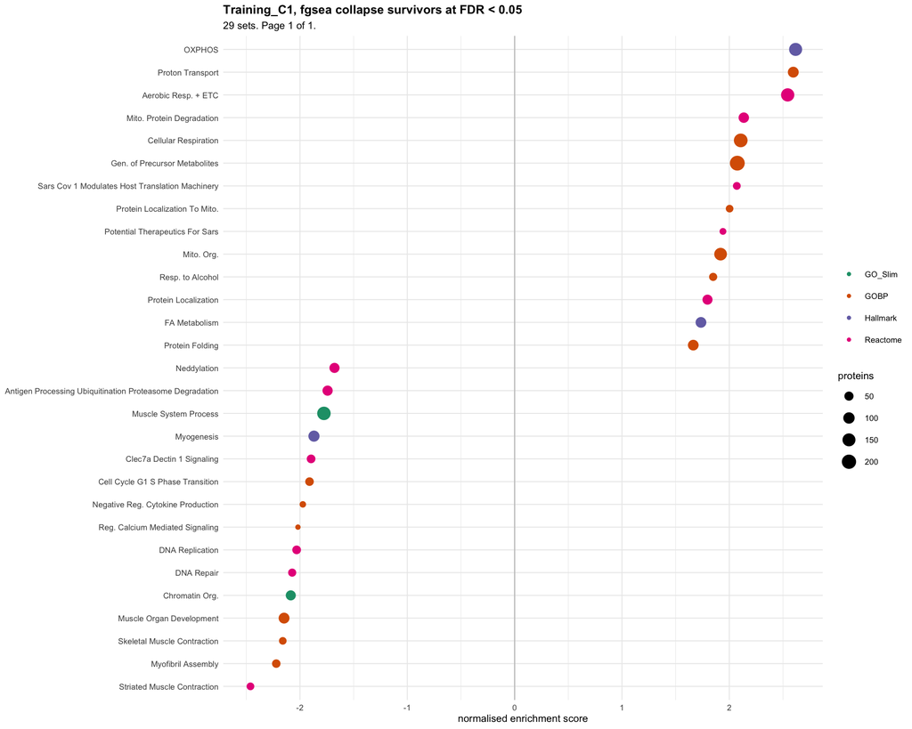

Figure 1: Sets called per contrast: fgsea collapse survivors, then fry sets at p < 0.05.

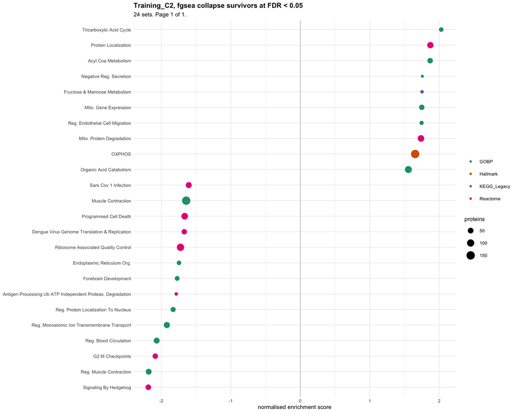

Figure 2: Sets called per contrast: fgsea collapse survivors, then fry sets at p < 0.05.

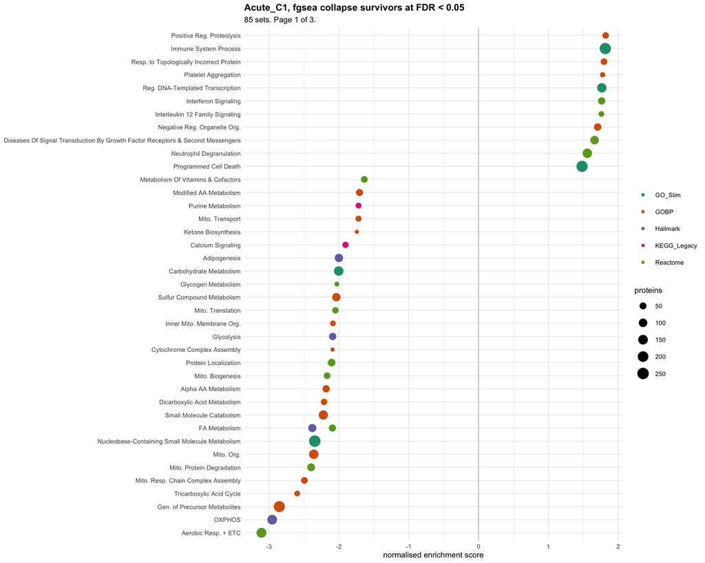

Figure 3: Sets called per contrast: fgsea collapse survivors, then fry sets at p < 0.05.

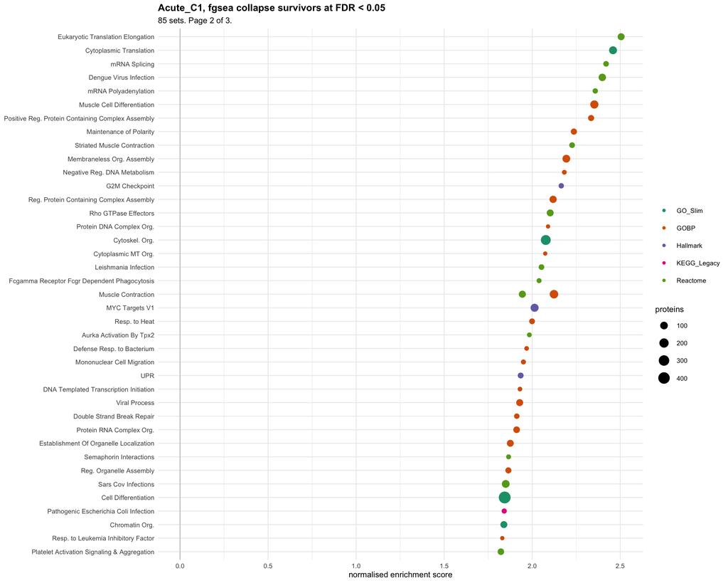

Figure 4: Sets called per contrast: fgsea collapse survivors, then fry sets at p < 0.05.

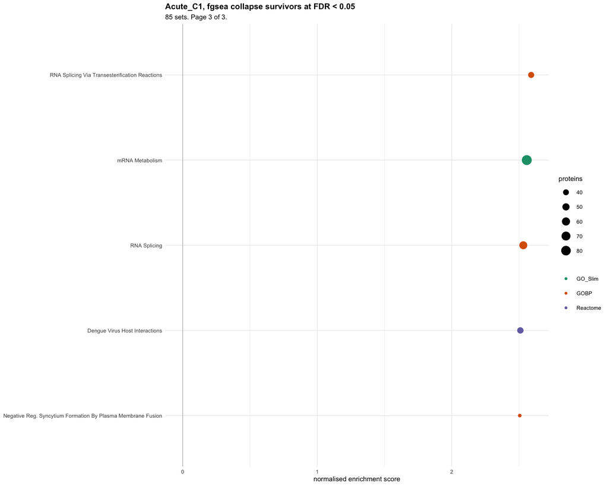

Figure 5: Sets called per contrast: fgsea collapse survivors, then fry sets at p < 0.05.

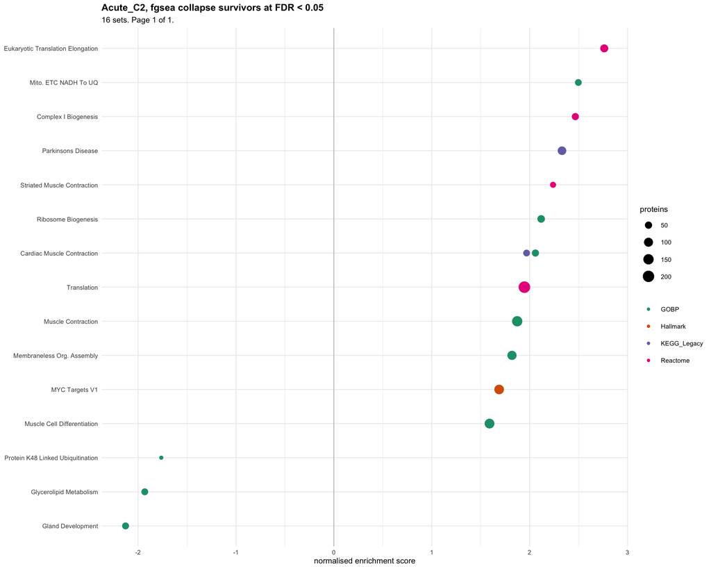

Figure 6: Sets called per contrast: fgsea collapse survivors, then fry sets at p < 0.05.

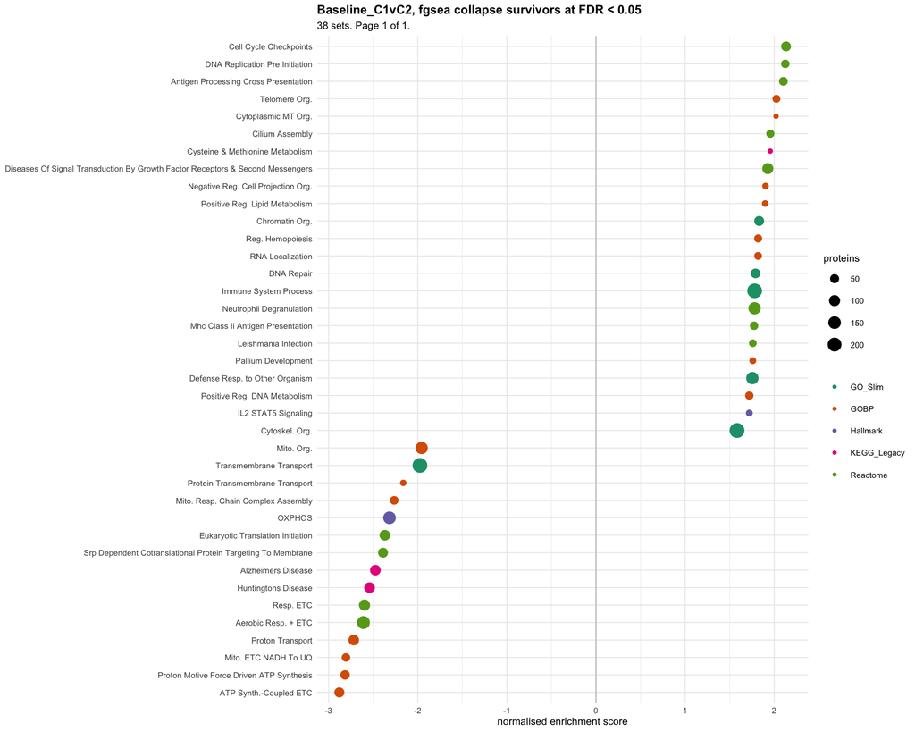

Figure 7: Sets called per contrast: fgsea collapse survivors, then fry sets at p < 0.05.

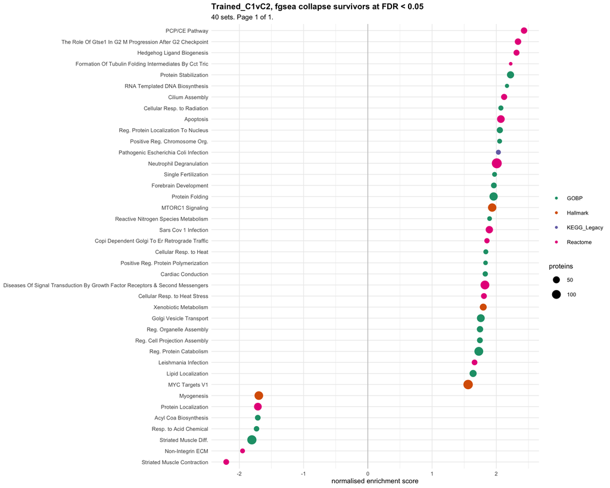

Figure 8: Sets called per contrast: fgsea collapse survivors, then fry sets at p < 0.05.

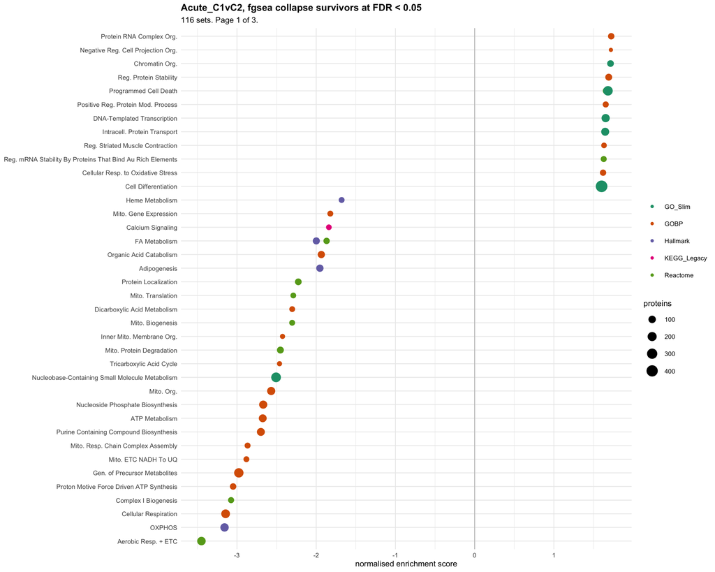

Figure 9: Sets called per contrast: fgsea collapse survivors, then fry sets at p < 0.05.

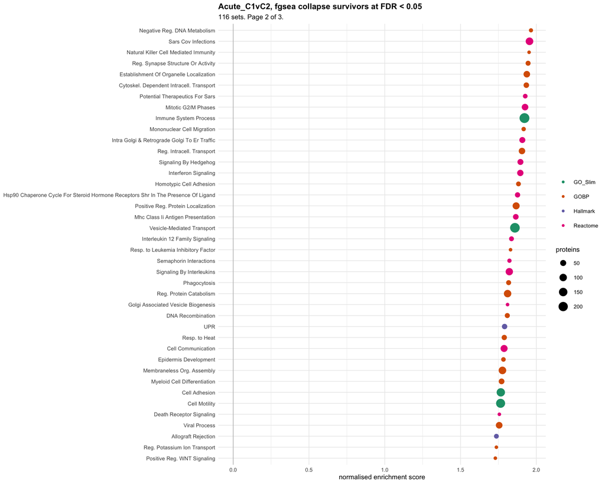

Figure 10: Sets called per contrast: fgsea collapse survivors, then fry sets at p < 0.05.

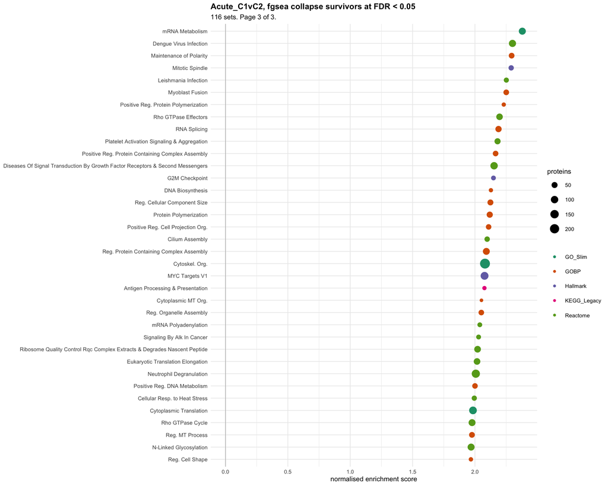

Figure 11: Sets called per contrast: fgsea collapse survivors, then fry sets at p < 0.05.

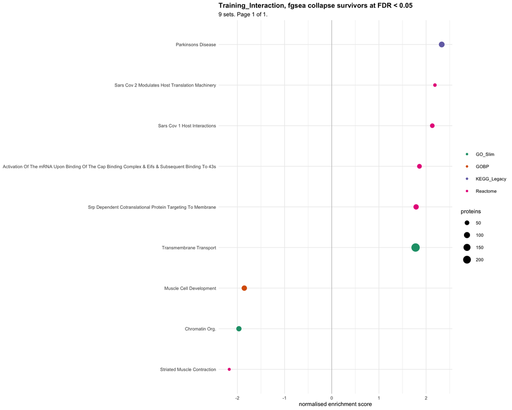

Figure 12: Sets called per contrast: fgsea collapse survivors, then fry sets at p < 0.05.

[60 more figures not shown]

```r
walk(pages, print)
```

## Every set at a glance

As for proteins: every set’s singscore across biopsies (centred on the set’s mean), then its fgsea NES across the nine contrasts, one pair of pages per collection. Rows follow average-linkage clustering on 1 − Pearson r of singscore within collection, for display only.

```r
catalog <- filter(gs$set_catalog, qualifies)
sample_values <- subset_for_design(readRDS(paths[["singscore"]]), d)$scores[catalog$set_id, ]
feature_label <- with(catalog, set_names(enrichVolcano::ev_clean_label(pathway), set_id))
contrast_results <- set_tests |>
  filter(method == "fgsea") |>
  transmute(feature = set_id, contrast, effect = nes, p, fdr)
row_groups <- split(catalog$set_id, factor(catalog$collection, unique(catalog$collection))) |>
  map(\(ids) ids[hclust(as.dist(1 - cor(t(sample_values[ids, ]))), "average")$order])
report_arm_colours <- set_names(c("#2166AC", "#B2182B"), d$arms)
trait_table <- readr::read_csv(paths[["phenotype"]], show_col_types = FALSE)
biopsy_traits <- trait_table |>
  select(subject, matches("_(pre|post)_")) |>
  pivot_longer(-subject, names_to = c("trait", "when"), names_pattern = "(.*)_(pre|post)_.*") |>
  pivot_wider(names_from = trait) |>
  transmute(
    subject,
    timepoint = if_else(when == "pre", "T1", "T2"), fcsa_mixed, mcsa, leg_press_1rm
  )
columns <- as_tibble(complete$metadata) |>
  transmute(sample_id, subject, arm = as.character(arm), timepoint = as.character(timepoint)) |>
  mutate(group = factor(
    paste(arm, timepoint, sep = "_"),
    paste(rep(d$arms, each = 3), c("T1", "T2", "T3"), sep = "_")
  )) |>
  left_join(biopsy_traits, by = c("subject", "timepoint")) |>
  left_join(select(trait_table, subject, comp_hypertrophy), by = "subject") |>
  arrange(group, subject)
stopifnot(!anyDuplicated(columns$sample_id), setequal(columns$sample_id, colnames(sample_values)))
lengths(row_groups)
```

```
   Hallmark    Reactome KEGG_Legacy        GOBP     GO_Slim
         33         328          62         897          58
```

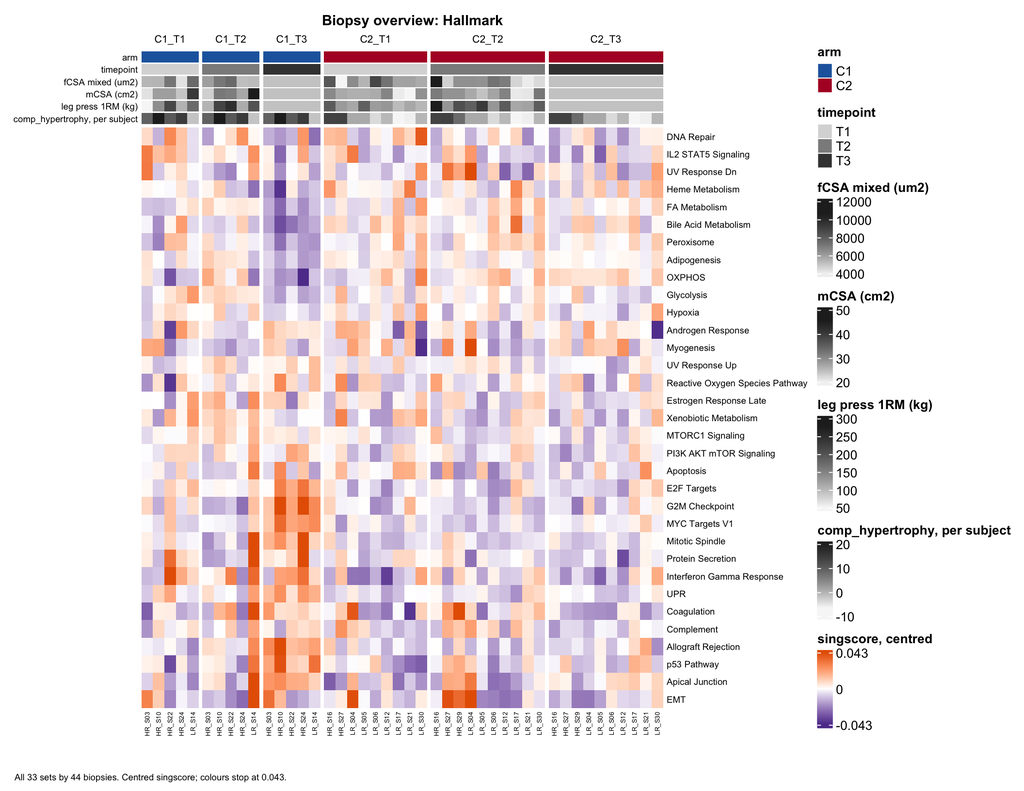

Figure 73: Every set across biopsies, then across the nine contrasts, by collection.

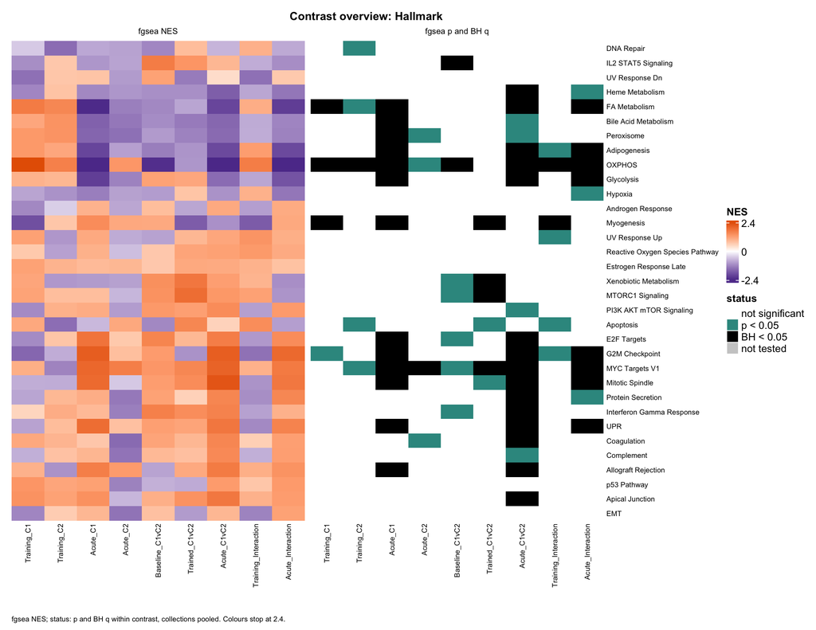

Figure 74: Every set across biopsies, then across the nine contrasts, by collection.

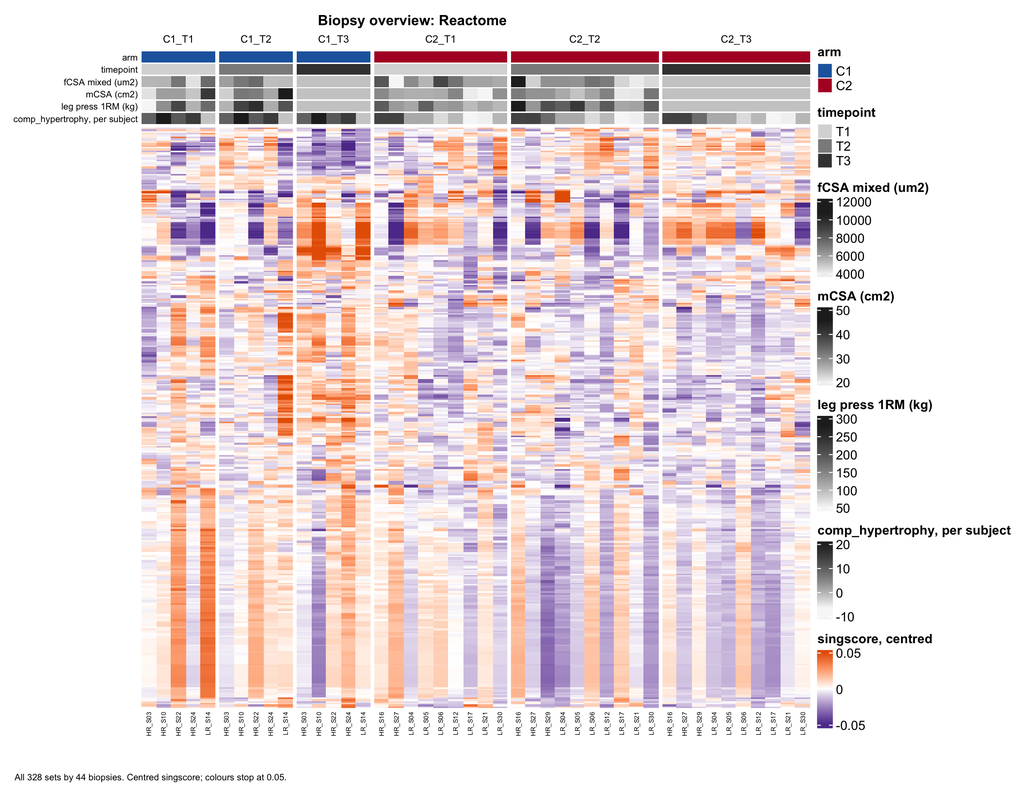

Figure 75: Every set across biopsies, then across the nine contrasts, by collection.

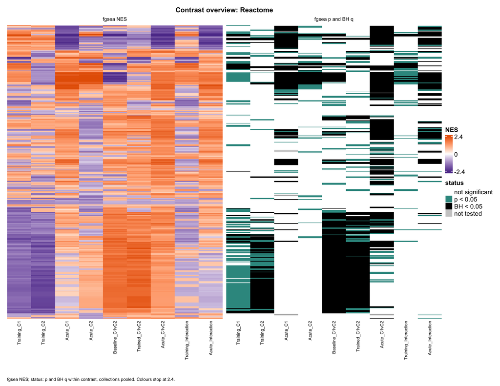

Figure 76: Every set across biopsies, then across the nine contrasts, by collection.

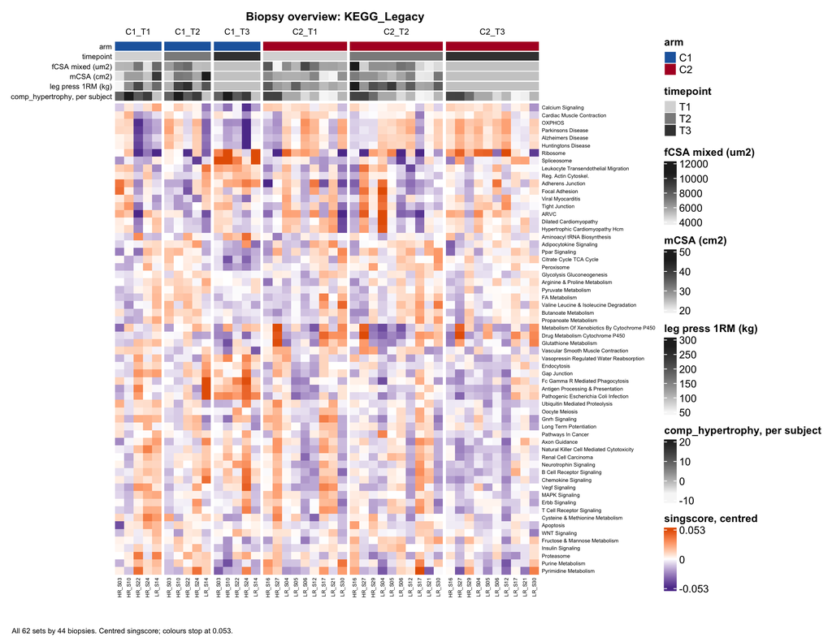

Figure 77: Every set across biopsies, then across the nine contrasts, by collection.

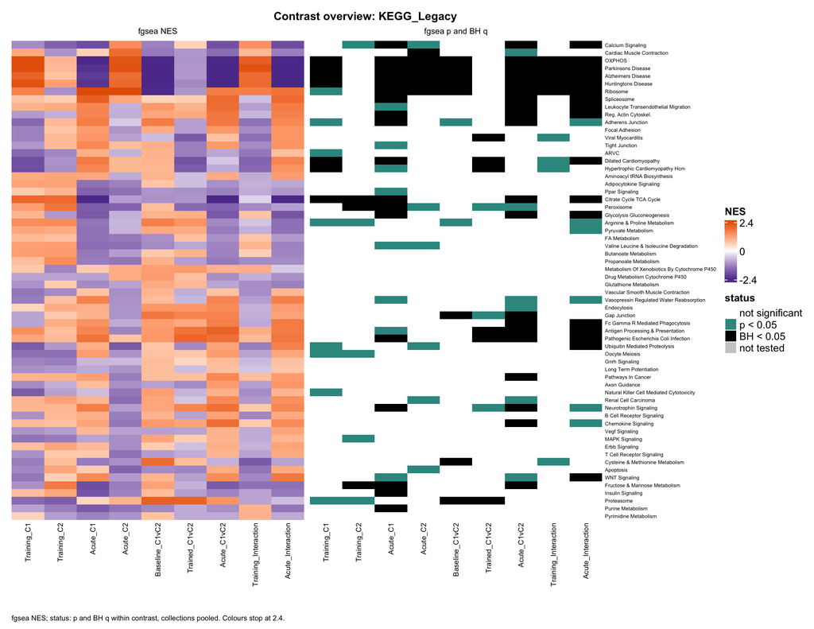

Figure 78: Every set across biopsies, then across the nine contrasts, by collection.

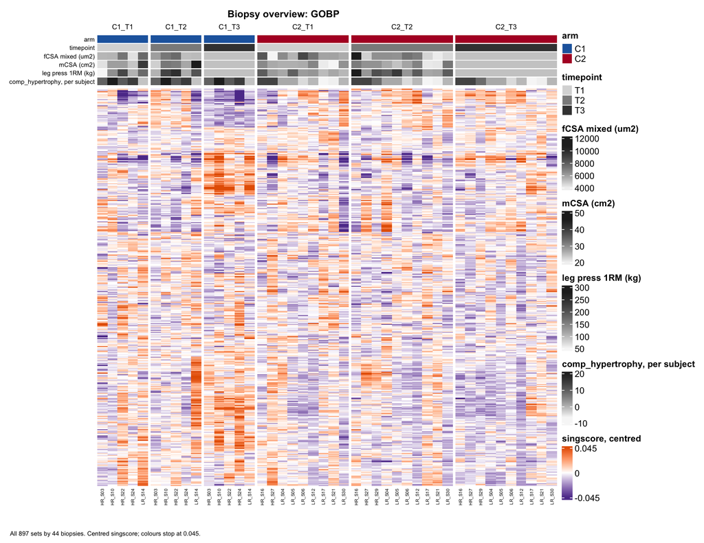

Figure 79: Every set across biopsies, then across the nine contrasts, by collection.

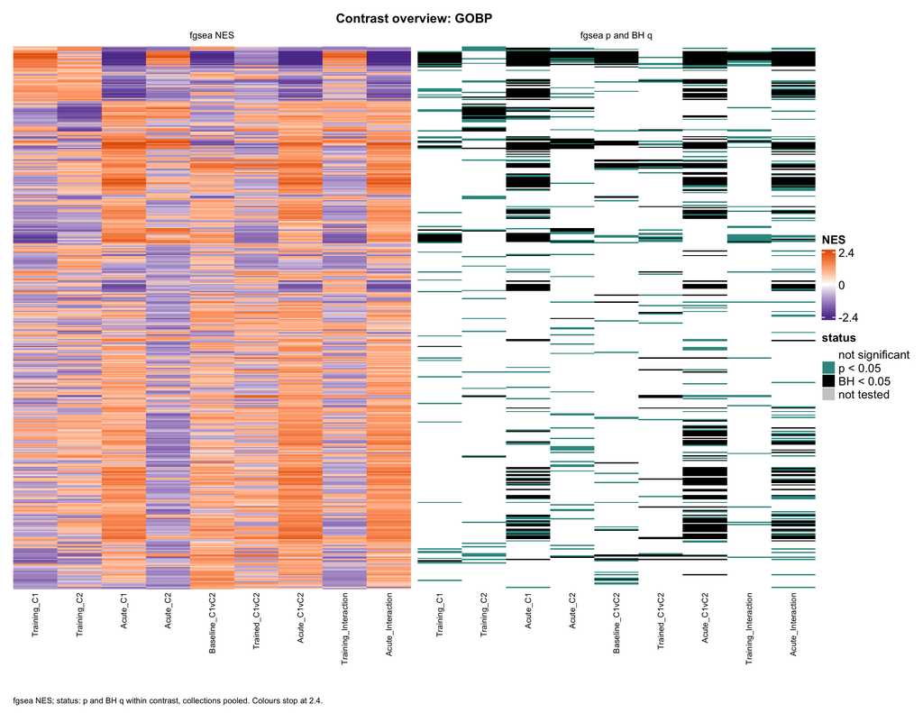

Figure 80: Every set across biopsies, then across the nine contrasts, by collection.

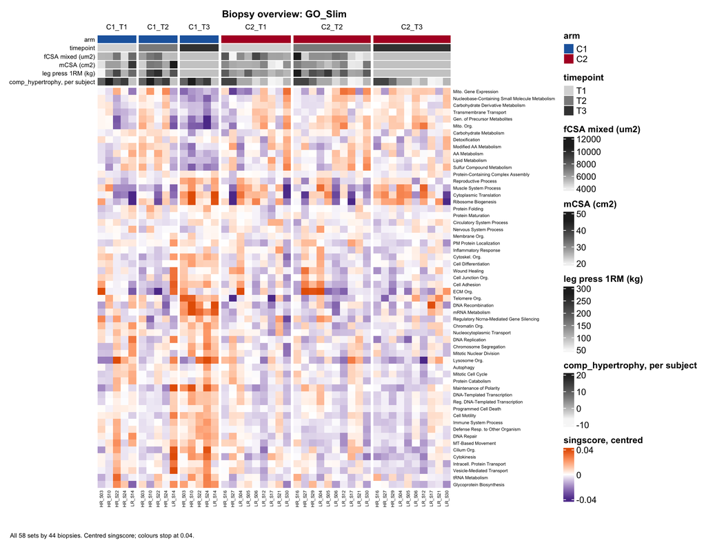

Figure 81: Every set across biopsies, then across the nine contrasts, by collection.

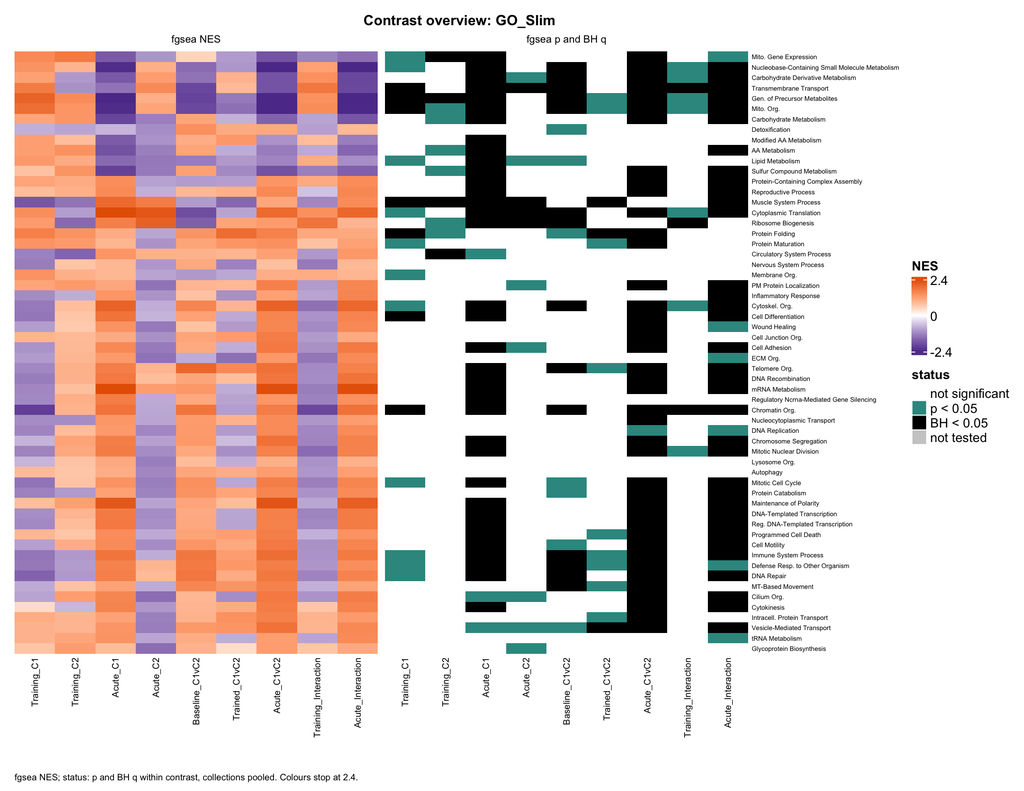

Figure 82: Every set across biopsies, then across the nine contrasts, by collection.

```r
grey_ramp <- \(x) circlize::colorRamp2(range(x, na.rm = TRUE), c("#F7F7F7", "#252525"))
tracks <- list(
  "fCSA mixed (um2)" = columns$fcsa_mixed,
  "mCSA (cm2)" = columns$mcsa, "leg press 1RM (kg)" = columns$leg_press_1rm,
  "comp_hypertrophy, per subject" = columns$comp_hypertrophy
)
sample_annotation <- HeatmapAnnotation(
  df = data.frame(arm = columns$arm, timepoint = columns$timepoint, tracks, check.names = FALSE),
  col = c(
    list(arm = report_arm_colours, timepoint = c(T1 = "grey85", T2 = "grey55", T3 = "grey25")),
    map(tracks, grey_ramp)
  ),
  na_col = "grey80", annotation_name_gp = gpar(fontsize = 7), annotation_name_side = "left",
  simple_anno_size = unit(3, "mm")
)
effect_limit <- cap(contrast_results$effect)
overviews <- imap(row_groups, \(rows, group) {
  m <- sample_values[rows, columns$sample_id, drop = FALSE]
  m <- sweep(m, 1, rowMeans(m))
  limit <- cap(m)
  labelled_heat <- \(...) make_report_heatmap(..., labels = feature_label)
  biopsy_map <- labelled_heat(m, "biopsies", c(-limit, 0, limit), "singscore, centred",
    row_names = TRUE, column_title = character(0), top_annotation = sample_annotation,
    column_split = columns$group, cluster_column_slices = FALSE,
    column_labels = columns$subject, column_names_gp = gpar(fontsize = 5)
  )
  contrast_grid <- \(value) {
    results_to_matrix(contrast_results, rows, contrast_names, "contrast", value)
  }
  contrast_maps <- labelled_heat(
    contrast_grid(\(d) d$effect), "fgsea NES", c(-effect_limit, 0, effect_limit), "NES"
  ) +
    labelled_heat(contrast_grid(\(d) status_of(d$p, d$fdr)), "fgsea p and BH q", row_names = TRUE)
  list(
    heatmap_page(biopsy_map, sprintf("Biopsy overview: %s", group), paste(
      sprintf("All %d sets by %d biopsies.", length(rows), ncol(m)),
      sprintf("Centred singscore; colours stop at %.2g.", limit)
    ), legends = list()),
    heatmap_page(contrast_maps, sprintf("Contrast overview: %s", group), paste(
      "fgsea NES; status: p and BH q within contrast, collections pooled.",
      sprintf("Colours stop at %.2g.", effect_limit)
    ))
  )
}) |>
  list_flatten()
walk(overviews, \(page) page$draw())
```

## Validation

```r
stopifnot(
  nrow(filter(set_tests, method == "fry")) == length(sets) * length(contrast_names),
  all(set_tests$fdr >= set_tests$p, na.rm = TRUE),
  all(filter(set_tests, method == "fgsea")$set_id %in% names(sets))
)
```

## Summary

```r
fgsea_calls <- filter(set_summary, contrast != d$floor)$n_fdr_fgsea
```

1378 sets were tested per contrast. fgsea calls 41 to 471 sets at FDR < 0.05 across the contrasts other than the floor, which calls 220. fry calls 1216 set-contrast pairs at FDR < 0.05 across all nine.

## Save

`set_tests.rds` holds every protein result and every set test; the figures and the classification step read it.

```r
out <- here(stage, "c_data")
dir.create(out, recursive = TRUE, showWarnings = FALSE)
saveRDS(
  list(protein_results = protein_results, set_tests = set_tests),
  file.path(out, "set_tests.rds"),
  compress = "xz"
)
write_workbook(
  list(
    set_summary = set_summary,
    significant = set_tests |>
      filter(fdr < 0.05) |>
      mutate(leading_edge = map_chr(leading_edge, paste, collapse = ";")),
    protein_summary = protein_summary,
    fry_correlation = tibble(matrix = "limpa", correlation = correlation)
  ),
  c(
    "Sets tested and called per contrast by method, and fgsea collapse survivors.",
    "Every set at FDR < 0.05, either method. The full table is set_tests in set_tests.rds.",
    "Proteins tested and at BH < 0.05 per contrast.",
    "Within-subject correlation fry used, estimated on limpa's matrix."
  ),
  file.path(out, "set_contrasts.xlsx"),
  inputs, paths
)
```

```r
stack_inputs(here("03_Group_comparisons", "Proteome", "03_Set_Contrasts"))
```